# Session 2 — Simple Linear Regression

Equation · prediction · residuals · R² · centering · Topics 3–4 · Lab 2

Community Medicine Workshop

## Where we are

- Session 1: regression models the **average outcome** as a function of predictors
- Today: the simplest case — **one continuous predictor**, **one continuous outcome**
- By the end you can:
  - write and read the equation, **in units**
  - **predict**, and know when to use a **confidence** vs a **prediction** interval
  - explain **residuals** and **OLS** without calculus
  - report **R²** and **adjusted R²** sensibly
  - **centre** predictors so the intercept means something

# Topic 3 — The straight-line model

## The equation

SBP<sub>i</sub> = β<sub>0</sub> + β<sub>1</sub> × salt<sub>i</sub> + ε<sub>i</sub>

- **β₀ (intercept)** — average SBP when salt = 0
- **β₁ (slope)** — change in average SBP for **each 1-unit increase** in salt (**mmHg per g/day**)
- **ε (error / residual)** — everything else that makes person *i* differ from the line

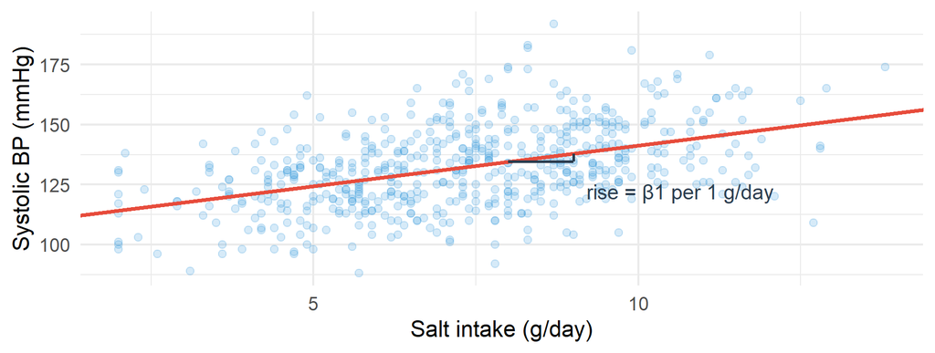

## Fit it with `lm()`

```r
m1 <- lm(sbp ~ salt_g, data = ncd)
summary(m1)
```

```
Call:
lm(formula = sbp ~ salt_g, data = ncd)

Residuals:
    Min      1Q  Median      3Q     Max
-41.857 -10.844  -0.434   9.888  55.093

Coefficients:
            Estimate Std. Error t value Pr(>|t|)
(Intercept) 107.4202     2.1490   49.98   <2e-16 ***
salt_g        3.3893     0.2801   12.10   <2e-16 ***
---
Signif. codes:  0 '***' 0.001 '**' 0.01 '*' 0.05 '.' 0.1 ' ' 1

Residual standard error: 15.14 on 580 degrees of freedom
  (18 observations deleted due to missingness)
Multiple R-squared:  0.2015,    Adjusted R-squared:  0.2001
F-statistic: 146.4 on 1 and 580 DF,  p-value: < 2.2e-16
```

## Interpretation — always in units

Each extra **1 g/day** of salt → mean SBP **3.4 mmHg** higher

- “mmHg per g/day” — the slope carries **units of the outcome over units of the predictor**
- This is a **crude** estimate (no other variables yet) — Session 3 adjusts it
- It describes an **association across people**, not what happens if one person changes their diet

## The unit you choose changes the number

```r
tibble(
  `Predictor unit`    = c("per 1 g/day", "per 5 g/day", "per 1 SD of salt"),
  `Change in SBP (mmHg)` = round(b1 * c(1, 5, sd(ncd$salt_g, na.rm = TRUE)), 1)
)
```

```
# A tibble: 3 × 2
  `Predictor unit` `Change in SBP (mmHg)`
  <chr>                             <dbl>
1 per 1 g/day                         3.4
2 per 5 g/day                        16.9
3 per 1 SD of salt                    7.6
```

Same model, same data — three different-looking numbers. Always report **the unit**, and pick an increment that is **clinically meaningful** (5 g ≈ a teaspoon of salt).

## The intercept

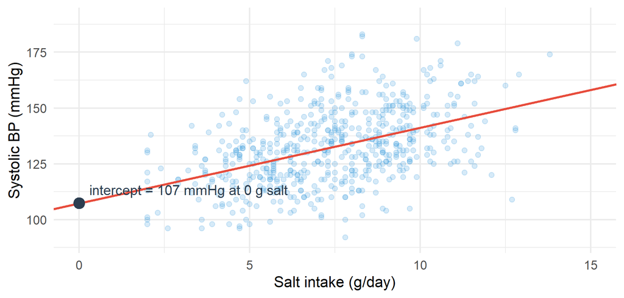

No one in the survey eats 0 g of salt — the intercept is an **extrapolation**. Keep that in mind: we return to it under *centering*.

# Prediction

## Predict with `predict()`

```r
new_salt <- tibble(salt_g = c(5, 8, 12))
predict(m1, newdata = new_salt)
```

```
       1        2        3
124.3668 134.5349 148.0922
```

“Adults who eat 8 g/day have a **mean** SBP of about 135 mmHg.”

Predict only **within the range of the data** (about 2–14 g/day). Beyond it, the straight line is a guess.

## Two different questions, two different intervals

**Confidence interval**

“What is the **average** SBP of *all* adults who eat 8 g/day?”

→ uncertainty about the **line**

**Prediction interval**

“What SBP might the **next patient** who eats 8 g/day have?”

→ line uncertainty **plus** person-to-person scatter

## CI vs PI in R: `interval =`

```r
predict(m1, new_salt, interval = "confidence") |> round(1)   # for the MEAN
```

```
    fit   lwr   upr
1 124.4 122.6 126.1
2 134.5 133.2 135.8
3 148.1 145.2 150.9
```

```r
predict(m1, new_salt, interval = "prediction") |> round(1)   # for an INDIVIDUAL
```

```
    fit   lwr   upr
1 124.4  94.6 154.2
2 134.5 104.8 164.3
3 148.1 118.2 178.0
```

At 8 g/day: mean SBP **135** (95% CI 133–136) but an individual may lie anywhere from **105** to **164**.

## Both bands on one plot

```r
grid <- tibble(salt_g = seq(2, 14, length.out = 100))
ci <- predict(m1, grid, interval = "confidence") |> as_tibble() |> rename(ci_lwr = lwr, ci_upr = upr)
pi <- predict(m1, grid, interval = "prediction") |> as_tibble() |> select(pi_lwr = lwr, pi_upr = upr)

bind_cols(grid, ci, pi) |>
  ggplot(aes(salt_g)) +
  geom_point(data = ncd, aes(y = sbp), alpha = .25, colour = col_blue) +
  geom_ribbon(aes(ymin = pi_lwr, ymax = pi_upr), fill = col_blue, alpha = .15) +
  geom_ribbon(aes(ymin = ci_lwr, ymax = ci_upr), fill = col_red, alpha = .5) +
  geom_line(aes(y = fit), colour = col_navy, linewidth = 1) +
  labs(x = "Salt intake (g/day)", y = "Systolic BP (mmHg)",
       caption = "Red = 95% CI for the mean · Blue = 95% prediction interval for an individual")
```

## Both bands on one plot

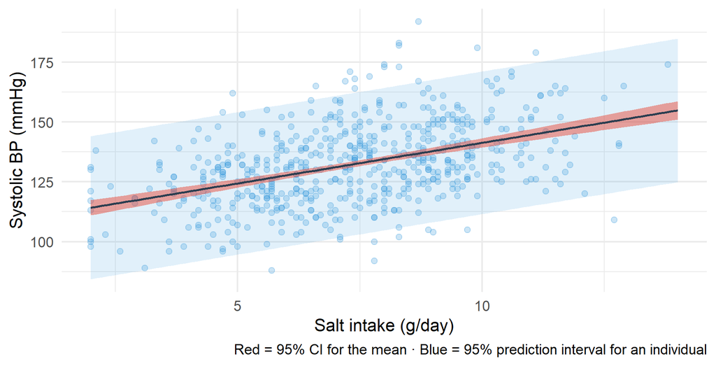

# Residuals and OLS

## Fitted values and residuals

**Fitted value** ŷ = what the line predicts for a person. **Residual** = observed − fitted.

```r
augment(m1) |> select(sbp, salt_g, .fitted, .resid) |> head(5) |> mutate(across(everything(), ~ round(.x, 1)))
```

```
# A tibble: 5 × 4
    sbp salt_g .fitted .resid
  <dbl>  <dbl>   <dbl>  <dbl>
1   131    6.9    131.    0.2
2   135    9      138.   -2.9
3   127    5.8    127.   -0.1
4   155   10.2    142    13
5   138    6.3    129.    9.2
```

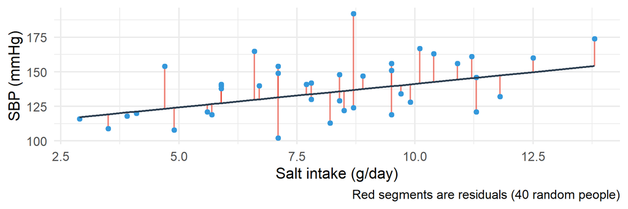

## OLS: choose the line with the smallest squared misses

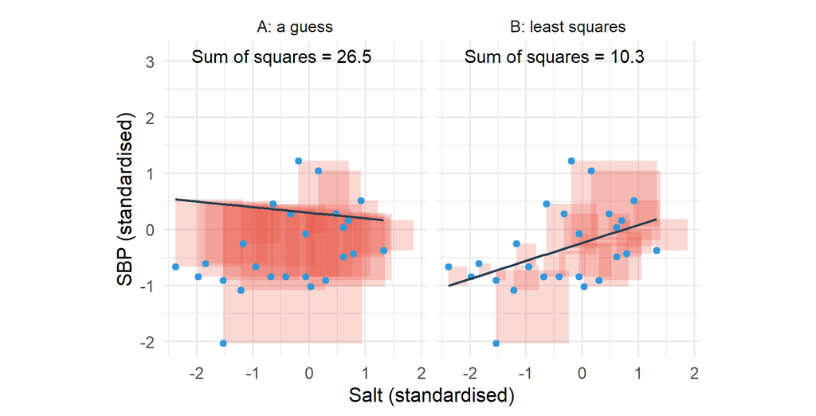

## Residuals vs fitted: first look

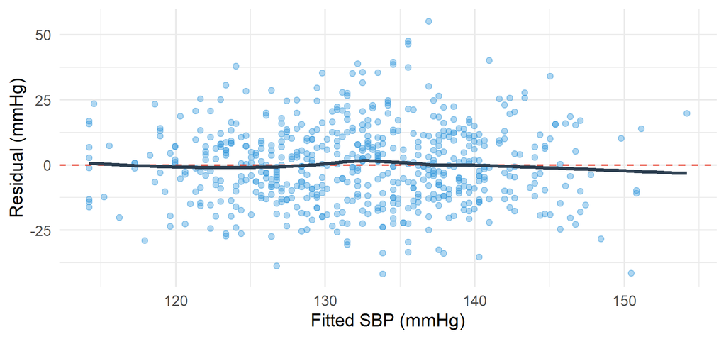

```r
augment(m1) |>
  ggplot(aes(.fitted, .resid)) +
  geom_point(alpha = .4, colour = col_blue) +
  geom_hline(yintercept = 0, linetype = "dashed", colour = col_red) +
  geom_smooth(se = FALSE, colour = col_navy, method = "loess", formula = y ~ x) +
  labs(x = "Fitted SBP (mmHg)", y = "Residual (mmHg)")
```

Residuals should scatter evenly around 0. Hold that thought — Session 4 reads this plot properly.

# R² and adjusted R²

## R²: how much of the variation does the model account for?

```r
r2(m1)
```

```
# R2 for Linear Regression
       R2: 0.202
  adj. R2: 0.200
```

```r
sigma(m1)   # residual standard error, in mmHg
```

```
[1] 15.13919
```

- R² = **0.2** → salt alone accounts for about **20%** of the variation in SBP
- **Residual SE ≈ 15 mmHg**: a typical miss — it is why the prediction interval is so wide

## R² always rises; adjusted R² punishes junk

```r
set.seed(2026)
junk <- as_tibble(matrix(rnorm(nrow(ncd) * 20), ncol = 20, dimnames = list(NULL, paste0("z", 1:20))))
d_j  <- bind_cols(ncd |> select(sbp, salt_g), junk) |> drop_na()

map_dfr(c(0, 5, 20), \(k) {
  f <- reformulate(c("salt_g", head(names(junk), k)), "sbp")
  s <- summary(lm(f, data = d_j))
  tibble(`random noise variables added` = k, R2 = round(s$r.squared, 3), `adjusted R2` = round(s$adj.r.squared, 3))
})
```

```
# A tibble: 3 × 3
  `random noise variables added`    R2 `adjusted R2`
                           <dbl> <dbl>         <dbl>
1                              0 0.202         0.2
2                              5 0.21          0.201
3                             20 0.227         0.198
```

Adding pure noise **raises R²** every time; **adjusted R²** charges for each extra parameter. Use adjusted R² when you compare models of different size.

## Reading R² sensibly

**A low R² does not mean the predictor is unimportant**

BP depends on age, genes, diet, stress… A salt slope can be real and clinically important with R² of 0.2.

**A high R² does not mean the model is right**

A model can fit well and still violate assumptions, or fit *this* dataset only (overfitting). R² says nothing about causation.

# Topic 4 — Centering and scaling

## An intercept at age 0?

```r
m_age <- lm(sbp ~ age, data = ncd)
coef(m_age)
```

```
(Intercept)         age
 96.3162078   0.7430034
```

The intercept says: a **0-year-old** has SBP **96 mmHg**. Our sample is aged 30–69, so this describes nobody.

## Centering: move the zero to a meaningful place

```r
ncd <- ncd |> mutate(age_c = age - 50)          # 0 now means "age 50"
m_age_c <- lm(sbp ~ age_c, data = ncd)

bind_rows(raw = tidy(m_age), centred = tidy(m_age_c), .id = "model") |>
  select(model, term, estimate) |> mutate(estimate = round(estimate, 2))
```

```
# A tibble: 4 × 3
  model   term        estimate
  <chr>   <chr>          <dbl>
1 raw     (Intercept)    96.3
2 raw     age             0.74
3 centred (Intercept)   133.
4 centred age_c           0.74
```

- **Slope unchanged** (0.74 mmHg per year)
- **Intercept now = expected SBP at age 50** = 133 mmHg → interpretable
- Centre on the **mean** or on a **clinically meaningful value** (age 50, BMI 25)

## Same line, new origin

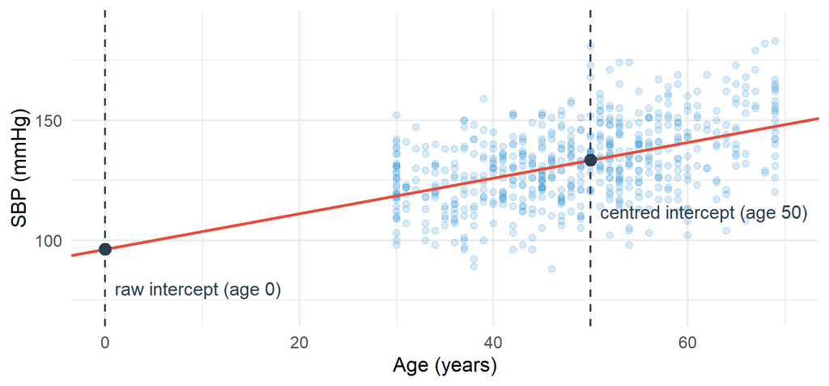

## Scaling: change the unit, not the relationship

```r
tidy(lm(sbp ~ I(age / 10), data = ncd)) |> select(term, estimate) |> mutate(estimate = round(estimate, 2))   # per 10 years
```

```
# A tibble: 2 × 2
  term        estimate
  <chr>          <dbl>
1 (Intercept)    96.3
2 I(age/10)       7.43
```

```r
tidy(lm(sbp ~ scale(age), data = ncd))  |> select(term, estimate) |> mutate(estimate = round(estimate, 2))   # per 1 SD
```

```
# A tibble: 2 × 2
  term        estimate
  <chr>          <dbl>
1 (Intercept)    132.
2 scale(age)       7.8
```

- **Per 10 years** reads naturally (“each decade of age adds …”)
- **Per SD** (standardised) lets you compare predictors measured in different units — but loses clinical units; prefer natural units for reporting

## 🔧 Switch to R — Lab 2

**File:** `regression-workshop/labs/lab2_simple.R`

- `lm()` · `summary()` · tidy coefficients
- `predict()` with **both** interval types
- Residual plot · R² · centred model

**Time:** 30 minutes · answer Q1–Q6 in the comments

## Self-check quiz (1/5)

The model sbp ~ salt_g gives a slope of 3.4. Which is the best interpretation?

- Salt intake raises systolic pressure by 3.4 percent per gram
- Each extra 1 g/day of salt goes with 3.4 mmHg higher mean SBP
- Salt accounts for 3.4 mmHg of the SBP of each person studied
- A person who adds 1 g of salt will see their SBP rise by 3.4 mmHg

## Self-check quiz (2/5)

A clinician wants the range within which the SBP of the NEXT patient eating 8 g/day is likely to fall. Which interval?

- 95% confidence interval for the mean
- 95% prediction interval
- Standard error of the slope
- Range of the sample

## Self-check quiz (3/5)

After centering age at 50 in `lm(sbp ~ age_c)`, what does the intercept represent?

- SBP of a newborn
- The change in SBP per year of age
- Expected mean SBP at age 50
- The residual standard error

## Self-check quiz (4/5)

Residual SD is about 15 mmHg. A 95% prediction interval for ONE new patient is roughly the fitted mean plus or minus how many mmHg? (nearest 5)

## Self-check quiz (5/5)

Adding 20 pure-noise variables nudged R-squared up from 0.20 to 0.23. Which statistic should you read to judge whether they helped? (two words)

## Score and take-home

**Your score:**

- **Slope** = change in mean outcome per 1 predictor unit — always say the **units**
- **CI** → the mean; **PI** → an individual (always wider)
- **OLS** minimises the sum of squared residuals
- **R²** is descriptive; use **adjusted R²** to compare sizes; low R² ≠ unimportant
- **Centre** so the intercept is meaningful; **scale** to a clinically sensible unit

**Next:** Session 3 — inference, confounding and multiple regression